# IODS Course Final Project

Email: Wenzhong.Zhang@helsinki.fi

Wenzhong Zhang

11th December 2017

Abstract

The `human` data was explored with a focus on finding the relationship between gender imbalance and human development index (HDI). Four research questions were subsequently raised and check by statistical analysis with R codes. Linear regression, model validation, logistic regression, categorizing and clustering of the data were explored in the project. The results suggested that gender imbalance issues are more severe in underdeveloped and developing countries with lower HDI. And that using HDI, the teen birth rate would be quite accurately predicted.

# 1 **Research question**

Gender issues have become more and more heated topic world wide. The development of human was never balanced with the respect to gender equality. Certain countries are better while most developing and under-developed countries falling behind. In this final project of IODS course, I would like to explore more the relation of gender imbalance and human development index. Here are the hypothese to be tested by R codes:

1. The completeness of mean school education (`meaneduratio`) is positively related with the HDI (`hdi`).
2. The binary teen birth indicator (`teenbirth_high`) is related with the HDI (`hdi`), the rank differences between HDI and GNI (`gnirhdir`), and the secondary education ratio for female (`edu2F`).
3. The categorical variable (`hdi_d`) based on the human development cutoff points (see [here](http://hdr.undp.org/sites/default/files/hdr2015_technical_notes.pdf) for explanation) can be predicted by other variables (excluding `hdi`, of course).
4. Perform K-mean clustering on the data.

# 2 **Description of data wrangling and the data**

The data wrangling file can be found [here](https://github.com/timothyzwz/IODS-final/blob/master/Data/create_human.R). The original two data sets were downloaded from [here](http://s3.amazonaws.com/assets.datacamp.com/production/course_2218/datasets/human_development.csv) and [here](http://s3.amazonaws.com/assets.datacamp.com/production/course_2218/datasets/gender_inequality.csv). These two data sets were joined by “country” (`cty`) variable. The incomplete data was filtered out. The ratio of education completeness was added as a new column. The level of `hdi` was categorized into four degrees (`low`, `medium`, `high` and `very high`) according to the description. Some unnecessary data (unrelated to the hypothesis) was removed from the data.

Let’s explore the data first and I will explain the meaning of those vairables to you!

First, we read the data from the .txt file.

```r
human <- read.table("Data/human.txt")
```

Next, we take a look at the dimension and summary of the data. The data has 159 observations from 12 variables.

```r
dim(human)
```

```
## [1] 159  12
```

```r
str(human)
```

```
## 'data.frame':    159 obs. of  12 variables:
##  $ hdi           : num  0.944 0.935 0.93 0.923 0.922 0.916 0.916 0.915 0.913 0.913 ...
##  $ lifebirth     : num  81.6 82.4 83 80.2 81.6 80.9 80.9 79.1 82 81.8 ...
##  $ edutime       : num  17.5 20.2 15.8 18.7 17.9 16.5 18.6 16.5 15.9 19.2 ...
##  $ meanedu       : num  12.6 13 12.8 12.7 11.9 13.1 12.2 12.9 13 12.5 ...
##  $ gni           : int  64992 42261 56431 44025 45435 43919 39568 52947 42155 32689 ...
##  $ gnirhdir      : int  5 17 6 11 9 11 16 3 11 23 ...
##  $ teenbirth     : num  7.8 12.1 1.9 5.1 6.2 3.8 8.2 31 14.5 25.3 ...
##  $ edu2F         : num  97.4 94.3 95 95.5 87.7 96.3 80.5 95.1 100 95 ...
##  $ labF          : num  61.2 58.8 61.8 58.7 58.5 53.6 53.1 56.3 61.6 62 ...
##  $ meaneduratio  : num  0.72 0.644 0.81 0.679 0.665 ...
##  $ teenbirth_high: logi  FALSE FALSE FALSE FALSE FALSE FALSE ...
##  $ hdi_d         : Factor w/ 4 levels "high","low","med",..: 4 4 4 4 4 4 4 4 4 4 ...
```

```r
summary(human)
```

```
##       hdi           lifebirth        edutime         meanedu
##  Min.   :0.3480   Min.   :49.00   Min.   : 5.40   Min.   : 1.400
##  1st Qu.:0.5925   1st Qu.:66.30   1st Qu.:11.25   1st Qu.: 6.000
##  Median :0.7330   Median :74.20   Median :13.50   Median : 8.700
##  Mean   :0.7052   Mean   :71.75   Mean   :13.18   Mean   : 8.306
##  3rd Qu.:0.8310   3rd Qu.:77.35   3rd Qu.:15.20   3rd Qu.:10.900
##  Max.   :0.9440   Max.   :84.00   Max.   :20.20   Max.   :13.100
##       gni            gnirhdir          teenbirth          edu2F
##  Min.   :   581   Min.   :-46.0000   Min.   :  0.60   Min.   :  0.90
##  1st Qu.:  4532   1st Qu.: -8.0000   1st Qu.: 12.65   1st Qu.: 27.15
##  Median : 12040   Median :  2.0000   Median : 33.60   Median : 56.60
##  Mean   : 18039   Mean   :  0.7987   Mean   : 46.83   Mean   : 55.32
##  3rd Qu.: 24869   3rd Qu.: 11.0000   3rd Qu.: 71.65   3rd Qu.: 84.70
##  Max.   :123124   Max.   : 47.0000   Max.   :204.80   Max.   :100.00
##       labF        meaneduratio    teenbirth_high        hdi_d
##  Min.   :13.50   Min.   :0.1795   Mode :logical   high     :48
##  1st Qu.:44.45   1st Qu.:0.5226   FALSE:79        low      :34
##  Median :53.20   Median :0.6268   TRUE :80        med      :30
##  Mean   :52.43   Mean   :0.6126                   very_high:47
##  3rd Qu.:61.90   3rd Qu.:0.7400
##  Max.   :88.10   Max.   :0.9412
```

The variables are summarized in the following table.

| Variable | Type | Meaning |
| --- | --- | --- |
| `hdi` | numeric | Human Development Index (HDI) |
| `lifebirth` | numeric | Life expectancy at birth |
| `edutime` | numeric | Expected years of schooling |
| `meanedu` | numeric | Mean years of schooling |
| `gni` | integer | Gross National Income (GNI) per capita |
| `gnirhdir` | integer | The ranking of GNI minus the ranking of HDI |
| `teenbirth` | numeric | Adolescent Birth Rate |
| `edu2F` | numeric | Population with Secondary Education (Female) |
| `labF` | numeric | Labour Force Participation Rate (Female) |
| `meaneduratio` | numeric | `meanedu`/`edutime` |
| `teenbirth_high` | logical | `TRUE` for the higher half of `teenbirth` |
| `hdi_d` | categorical | Four level categorical variable based on HDI level |

# 3 **Data overview**

The data is first plotted by the `ggpairs` function in the `ggplot2` package. The `hdi_d` variable was removed from this visualization since `ggpairs` has problem processing the data. Nevertheless, one can quite easily check the distribution of the data through Figure 1.

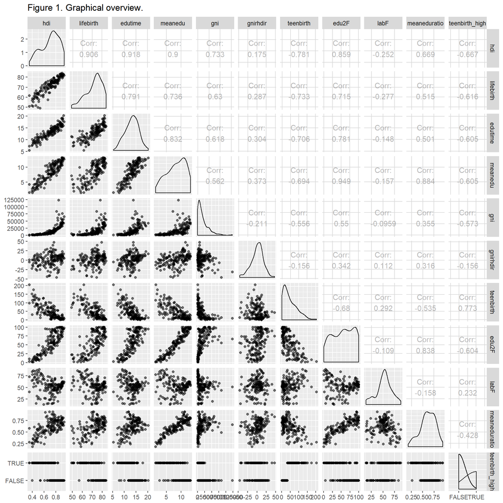

```r
library(ggplot2)
library(GGally)
human2 <- dplyr::select(human, -hdi_d)
p <- ggpairs(human2, mapping = aes(alpha = 0.9), lower = list(combo = wrap("facethist", bins = 20)), title = "Figure 1. Graphical overview.")
p
```

Subsequently, a correlation plot was established:

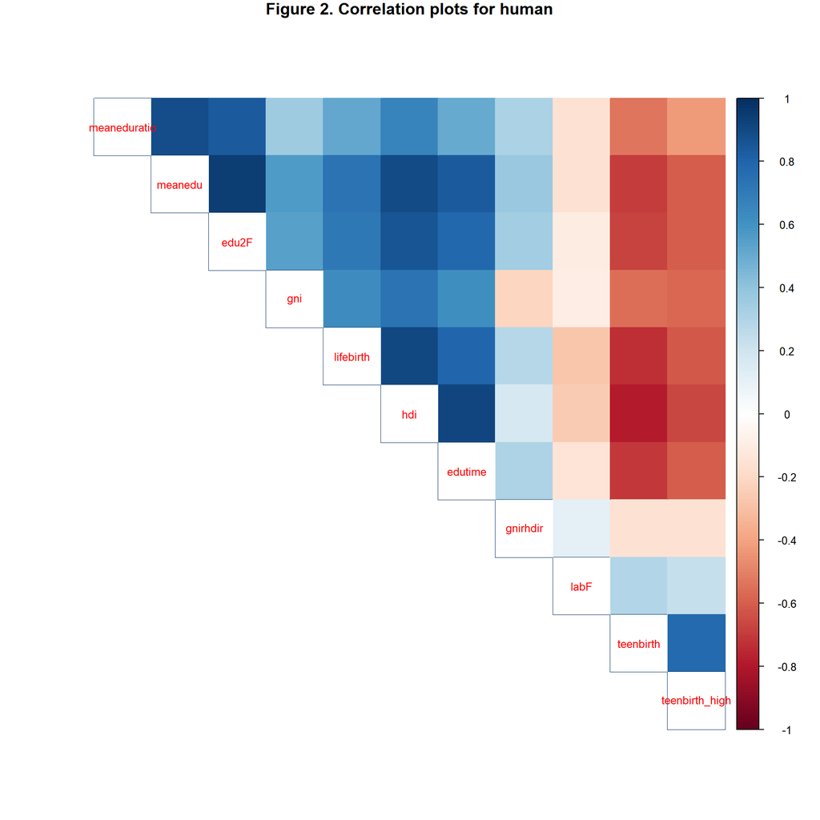

```r
library(corrplot)
library(magrittr)
cor(human2) %>% corrplot(method="color", order="hclust", type = "upper", cl.pos = "r", tl.pos = "d", tl.cex = 0.8, title = "Figure 2. Correlation plots for human", mar=c(0,0,1,0))
```

With regards to the previous three research questions, we can see from the data overview that:

1. The completeness of mean school education (`meaneduratio`) seems to be positively related with the HDI (`hdi`). However, during the analysis we include also `gni` and `lifebirth` variables.
2. The binary teen birth indicator (`teenbirth_high`) seems to be negatively related with the HDI (`hdi`) and the secondary education ratio for female (`edu2F`). However, the rank differences between HDI and GNI (`gnirhdir`) does not have visible relationship with the binary variable.
3. The other two research questions will be dealt with later.

# 4 **Data analysis**

## 4.1 **Linear regression and validation**

According to the assumption 1, the `meaneduratio` is fitted with `hdi`, `gni` and `lifebirth` variables linearly.

```r
regression <- lm(meaneduratio ~ hdi + gni + lifebirth, data = human)
```

The summary of the regression is shown here:

```r
summary(regression)
```

```
##
## Call:
## lm(formula = meaneduratio ~ hdi + gni + lifebirth, data = human)
##
## Residuals:
##      Min       1Q   Median       3Q      Max
## -0.27857 -0.07122 -0.00535  0.05634  0.36837
##
## Coefficients:
##               Estimate Std. Error t value Pr(>|t|)
## (Intercept)  4.058e-01  1.052e-01   3.858 0.000167 ***
## hdi          1.526e+00  1.565e-01   9.751  < 2e-16 ***
## gni         -2.879e-06  6.888e-07  -4.179 4.88e-05 ***
## lifebirth   -1.139e-02  2.548e-03  -4.469 1.51e-05 ***
## ---
## Signif. codes:  0 '***' 0.001 '**' 0.01 '*' 0.05 '.' 0.1 ' ' 1
##
## Residual standard error: 0.1117 on 155 degrees of freedom
## Multiple R-squared:  0.5455, Adjusted R-squared:  0.5367
## F-statistic: 62.02 on 3 and 155 DF,  p-value: < 2.2e-16
```

In the linear regreesion model, the assumptions are:

1. Linearity: the target variable is modelled as a linear combination of the model parameters.
2. Normally distributed errors.
3. The errors are not correlated.
4. The errors have constant variance.
5. The size of a given error does not depend on the explanatory variables.

The residuals provide a method to explore the validity of the model assumptions. The following diagnostic plots are produced (**Figure 3**):

- Residuals vs Fitted values (*assumption 4*);
- Normal QQ-plot (*assumption 2*);
- Residuals vs Leverage (*single observation impact*).

**Figure 3**. Residual Plots

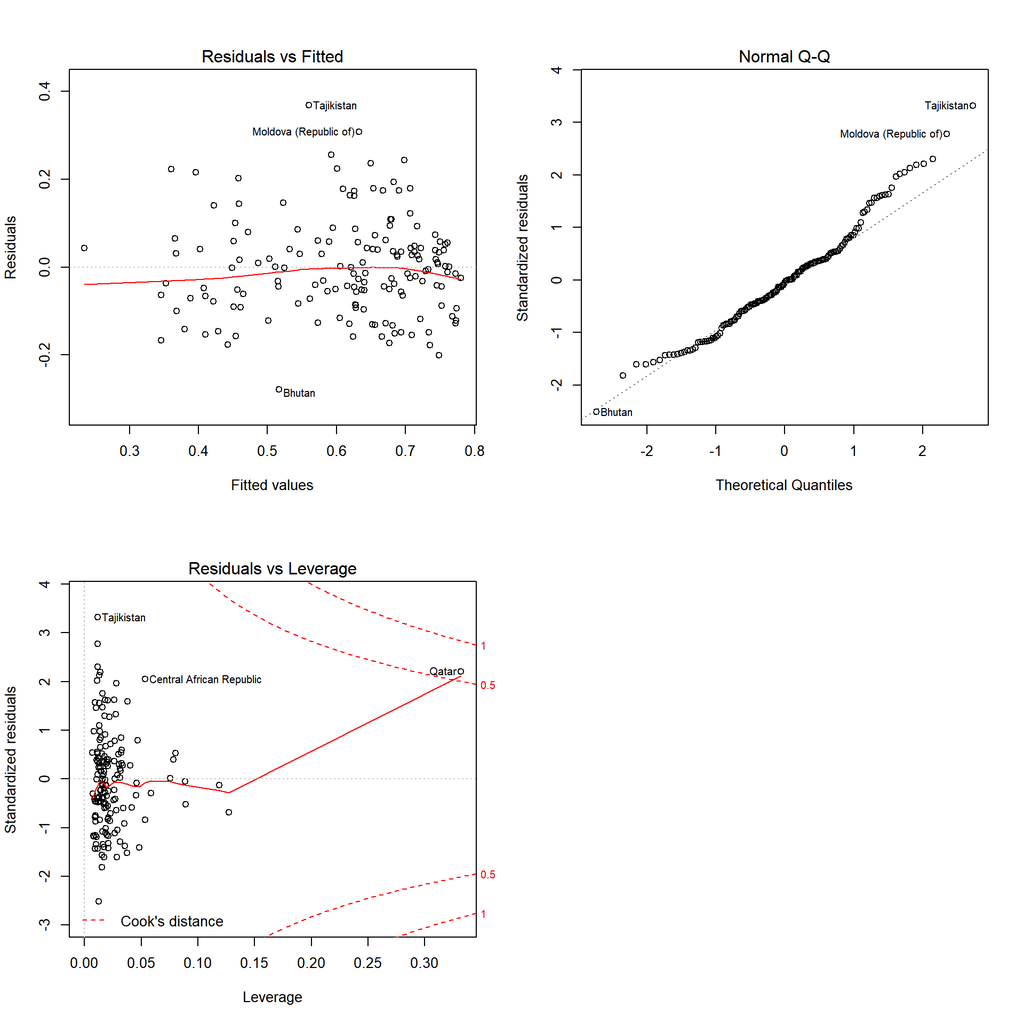

```r
par(mfrow = c(2,2))
plot(regression, which = c(1, 2, 5))
```

The following conclusions are drawn from the residual analysis:

- The Residuals vs Fitted values plot examines if the errors have constant variance. The graph shows a reasonable constant variance without any pattern.
- The Normal QQ-polt checks if the errors are normally distributed. We see from the graph a very good linear model fit, indicating a normally distributed error set.
- The Residuals vs Leverage confirms if there are any outliers with high leverage. From the graph, it shows that all the leverage are below 0.20 (except Qatar), indicating reasonably good model fitting.

The above analysis confirmed that research question 1 is correct.

## 4.2 **Logistic regression and validation**

The relationship between binary teen birth indicator (`teenbirth_high`) and the HDI (`hdi`), the rank differences between HDI and GNI (`gnirhdir`), and the secondary education ratio for female (`edu2F`) is explored via logistic regression.

```r
m <- glm(teenbirth_high ~ hdi + gnirhdir + edu2F, data = human, family = "binomial")
summary(m)
```

```
##
## Call:
## glm(formula = teenbirth_high ~ hdi + gnirhdir + edu2F, family = "binomial",
##     data = human)
##
## Deviance Residuals:
##      Min        1Q    Median        3Q       Max
## -3.12502  -0.61990   0.08462   0.56388   1.91220
##
## Coefficients:
##               Estimate Std. Error z value Pr(>|z|)
## (Intercept)  10.377141   1.919514   5.406 6.44e-08 ***
## hdi         -13.627863   3.129988  -4.354 1.34e-05 ***
## gnirhdir     -0.003442   0.013286  -0.259    0.796
## edu2F        -0.008922   0.013134  -0.679    0.497
## ---
## Signif. codes:  0 '***' 0.001 '**' 0.01 '*' 0.05 '.' 0.1 ' ' 1
##
## (Dispersion parameter for binomial family taken to be 1)
##
##     Null deviance: 220.41  on 158  degrees of freedom
## Residual deviance: 129.93  on 155  degrees of freedom
## AIC: 137.93
##
## Number of Fisher Scoring iterations: 5
```

```r
OR <- coef(m) %>% exp
CI <- confint(m) %>% exp
cbind(OR, CI)
```

```
##                       OR        2.5 %       97.5 %
## (Intercept) 3.211702e+04 1.010089e+03 1.994767e+06
## hdi         1.206408e-06 1.701540e-09 4.025467e-04
## gnirhdir    9.965640e-01 9.704247e-01 1.022857e+00
## edu2F       9.911177e-01 9.657309e-01 1.017179e+00
```

Odds ratios (OR) are used to compare the relative odds of the occurrence of the outcome of interest (`teenbirth_high`), given the change to the variable of interest (3 variables here).

**Table 1**. Comparison of ORs and their confidence intervals.

[output not shown]

From the results, we see that for `hdi`, the OR is well below 1 and their confidence intervals does not include 1. For `gnirhdir` and `edu2F`, the ORs are below 1 and their confidence interval span 1. To sum it up, only `hdi` is negatively related with `teenbirth_high`. The other two variables does not have statistical significant relationship with the binary variable.

The predictive power of the model is explored here:

```r
library(dplyr)
library(tidyr)
probabilities <- predict(m, type = "response")
human <- mutate(human, probability = probabilities)
human <- mutate(human, prediction = probability > 0.5)
```

The tabulation of predictions vs. the actual values is listed here:

```r
table(teenbirth_high = human$teenbirth_high, prediction = human$prediction)
```

```
##               prediction
## teenbirth_high FALSE TRUE
##          FALSE    67   12
##          TRUE     18   62
```

The graphic visualization of both the actual values and the predictions is provided here:

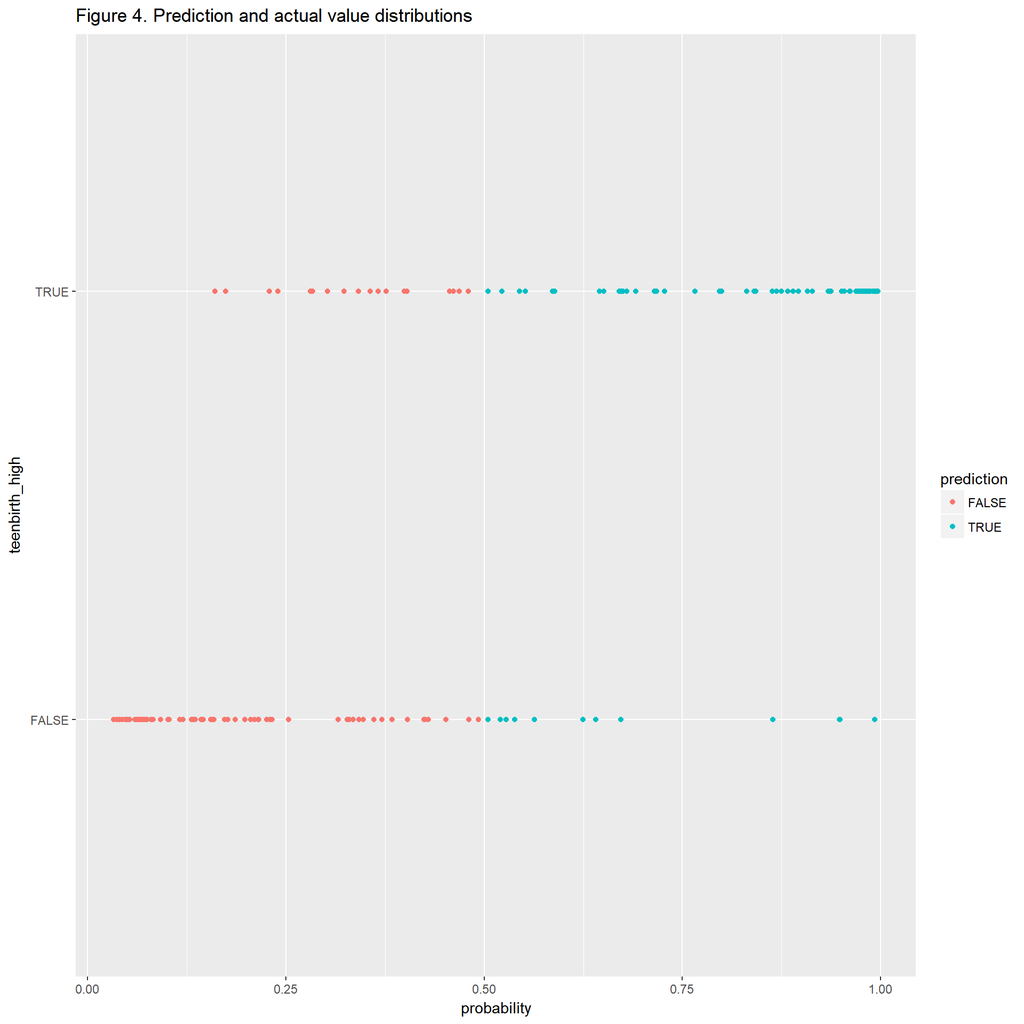

```r
g <- ggplot(human, aes(x = probability, y = teenbirth_high, col = prediction))
g + geom_point() + ggtitle('Figure 4. Prediction and actual value distributions')
```

The total proportion of inaccurately classified individuals (= the training error) is computed here:

```r
table(teenbirth_high = human$teenbirth_high, prediction = human$prediction) %>% prop.table() %>% addmargins()
```

```
##               prediction
## teenbirth_high     FALSE      TRUE       Sum
##          FALSE 0.4213836 0.0754717 0.4968553
##          TRUE  0.1132075 0.3899371 0.5031447
##          Sum   0.5345912 0.4654088 1.0000000
```

```r
loss_func <- function(class, prob) {
  n_wrong <- abs(class - prob) > 0.5
  mean(n_wrong)
}
loss_func(class = human$teenbirth_high, prob = human$prediction)
```

```
## [1] 0.1886792
```

10-fold cross-validation is performed subsequently. The prediction error is 0.20.

```r
library(boot)
cv <- cv.glm(data = human, cost = loss_func, glmfit = m, K = 10)
cv$delta[1]
```

```
## [1] 0.1949686
```

According to the correlation plot, let’s try to include more variables into the model and test its prediction power! `meanedu`, `lifebirth` and `edutime` variables are included now.

```r
m2 <- glm(teenbirth_high ~ hdi + meanedu + lifebirth + edutime, data = human, family = "binomial")
probabilities2 <- predict(m2, type = "response")
human <- mutate(human, probability2 = probabilities2)
human <- mutate(human, prediction2 = probability2 > 0.5)
loss_func(class = human$teenbirth_high, prob = human$prediction2)
```

```
## [1] 0.1886792
```

```r
cv2 <- cv.glm(data = human, cost = loss_func, glmfit = m2, K = 10)
cv2$delta[1]
```

```
## [1] 0.2012579
```

The research question 2 is partially correct, with only the `hdi` has negative correlation with `teenbirth_high`.

## 4.3 **Categorizing**

Clustering means that some points (or observations) of the data are in some sense closer to each other than some other points. In other words, the data points do not comprise a homogeneous sample, but instead, it is somehow clustered.

The `human` data is standardised and its summary printed here. Scaling of data may be useful and/or necessary under certain circumstances (e.g. when variables span different ranges). Standardization is the scaling procedure which results in a zero mean and unit variance of any descriptor variable. For every data value the mean μ has to be subtracted, and the result has to be divided by the standard deviation σ (note that the order of these two operations must not be reversed):

```r
library(tidyverse)
library(dplyr)
library(tidyr)
human <- read.table("Data/human.txt")
human2 <- dplyr::select(human, -hdi_d)
human2 <- dplyr::select(human2, -teenbirth_high)
human2_scaled <- scale(human2)
summary(human2_scaled)
```

```
##       hdi            lifebirth          edutime           meanedu
##  Min.   :-2.3103   Min.   :-2.7359   Min.   :-2.7596   Min.   :-2.2138
##  1st Qu.:-0.7289   1st Qu.:-0.6554   1st Qu.:-0.6852   1st Qu.:-0.7393
##  Median : 0.1799   Median : 0.2947   Median : 0.1126   Median : 0.1262
##  Mean   : 0.0000   Mean   : 0.0000   Mean   : 0.0000   Mean   : 0.0000
##  3rd Qu.: 0.8138   3rd Qu.: 0.6735   3rd Qu.: 0.7154   3rd Qu.: 0.8314
##  Max.   : 1.5447   Max.   : 1.4732   Max.   : 2.4884   Max.   : 1.5366
##       gni             gnirhdir          teenbirth           edu2F
##  Min.   :-0.9143   Min.   :-2.88332   Min.   :-1.1330   Min.   :-1.77369
##  1st Qu.:-0.7074   1st Qu.:-0.54210   1st Qu.:-0.8377   1st Qu.:-0.91812
##  Median :-0.3142   Median : 0.07401   Median :-0.3243   Median : 0.04176
##  Mean   : 0.0000   Mean   : 0.00000   Mean   : 0.0000   Mean   : 0.00000
##  3rd Qu.: 0.3577   3rd Qu.: 0.62851   3rd Qu.: 0.6081   3rd Qu.: 0.95763
##  Max.   : 5.5036   Max.   : 2.84651   Max.   : 3.8710   Max.   : 1.45631
##       labF          meaneduratio
##  Min.   :-2.3994   Min.   :-2.63987
##  1st Qu.:-0.4917   1st Qu.:-0.54896
##  Median : 0.0476   Median : 0.08617
##  Mean   : 0.0000   Mean   : 0.00000
##  3rd Qu.: 0.5838   3rd Qu.: 0.77660
##  Max.   : 2.1987   Max.   : 2.00247
```

```r
human2_scaled <- as.data.frame(human2_scaled)
```

The categorical varialbe `hdi_d` is re-added into the `human2_scaled` data. The data is glimpsed to make sure that all the changes are correctly done.

```r
human2_scaled <- data.frame(human2_scaled, human$hdi_d)
human2_scaled <- dplyr::select(human2_scaled, -hdi)
glimpse(human2_scaled)
```

```
## Observations: 159
## Variables: 10
## $ lifebirth    <dbl> 1.1846158, 1.2808251, 1.3529822, 1.0162494, 1.184...
## $ edutime      <dbl> 1.5309873, 2.4883840, 0.9281820, 1.9564969, 1.672...
## $ meanedu      <dbl> 1.3763153, 1.5045321, 1.4404237, 1.4083695, 1.151...
## $ gni          <dbl> 2.4590473, 1.2685623, 2.0106842, 1.3609478, 1.434...
## $ gnirhdir     <dbl> 0.25884410, 0.99817725, 0.32045520, 0.62851068, 0...
## $ teenbirth    <dbl> -0.9565693, -0.8511949, -1.1011528, -1.0227346, -...
## $ edu2F        <dbl> 1.3715647, 1.2705254, 1.2933407, 1.3096374, 1.055...
## $ labF         <dbl> 0.540698769, 0.392770285, 0.577680891, 0.38660659...
## $ meaneduratio <dbl> 0.65444134, 0.18858188, 1.20374424, 0.40543481, 0...
## $ human.hdi_d  <fctr> very_high, very_high, very_high, very_high, very...
```

Divide the dataset to train and test sets, so that 80% of the data belongs to the train set.

```r
n <- nrow(human2_scaled)
ind <- sample(n,  size = n * 0.8)
train <- human2_scaled[ind,]
test <- human2_scaled[-ind,]
correct_classes <- test$human.hdi_d
test <- dplyr::select(test, -human.hdi_d)
```

Linear Discriminant analysis is a classification (and dimension reduction) method. It finds the (linear) combination of the variables that separate the target variable classes. Here we fit the `human.hdi_d` variable by all other variables available in the dataset as predictors.

```r
library(MASS)
lda.fit <- lda(human.hdi_d ~ ., data = train)
lda.fit
```

```
## Call:
## lda(human.hdi_d ~ ., data = train)
##
## Prior probabilities of groups:
##      high       low       med very_high
## 0.2992126 0.1889764 0.2204724 0.2913386
##
## Group means:
##            lifebirth    edutime    meanedu        gni    gnirhdir
## high       0.3199973  0.2134004  0.3261180 -0.1924322  0.18750494
## low       -1.4621443 -1.3943916 -1.3442863 -0.8158558 -0.38037102
## med       -0.3963964 -0.4762532 -0.3809426 -0.5781085 -0.30005655
## very_high  0.9762705  1.0374344  0.8651805  1.2433625  0.01239972
##            teenbirth      edu2F        labF meaneduratio
## high      -0.2190127  0.2606464 -0.38336765   0.41838483
## low        1.0998659 -1.3454978  0.43642973  -1.08614535
## med        0.4373664 -0.3122306 -0.11837546  -0.06944032
## very_high -0.8072171  0.8431121 -0.05368055   0.44893452
##
## Coefficients of linear discriminants:
##                      LD1        LD2        LD3
## lifebirth    -1.87233977  0.9456285  0.1017253
## edutime      -0.96031031  3.1066120 -2.5161334
## meanedu      -1.70525677 -6.4249174  6.3749252
## gni          -0.34128606 -1.3584601 -0.6186550
## gnirhdir      0.55809207 -0.5358890  0.2057100
## teenbirth    -0.11777502  0.3549147 -0.5327882
## edu2F        -0.31717789  0.8183242 -1.8751597
## labF          0.06577167 -0.1797875 -0.1772063
## meaneduratio  0.59511182  4.1950582 -2.7493199
##
## Proportion of trace:
##    LD1    LD2    LD3
## 0.9305 0.0653 0.0042
```

The data is divided into four colours based on the `human.hdi_d` category and the plot below shows the LDA results of them.

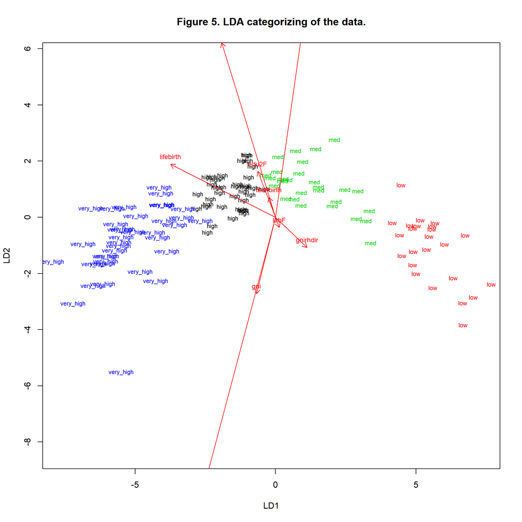

```r
lda.arrows <- function(x, myscale = 1, arrow_heads = 0.1, color = "red", tex = 0.75, choices = c(1,2)){
  heads <- coef(x)
  arrows(x0 = 0, y0 = 0,
         x1 = myscale * heads[,choices[1]],
         y1 = myscale * heads[,choices[2]], col=color, length = arrow_heads)
  text(myscale * heads[,choices], labels = row.names(heads),
       cex = tex, col=color, pos=3)
}
classes <- as.numeric(train$human.hdi_d)
plot(lda.fit, dimen = 2, col = classes, pch = classes, main = "Figure 5. LDA categorizing of the data.")
lda.arrows(lda.fit, myscale = 2)
```

The prediction of the classes with the LDA model on the test data was conducted.

```r
lda.pred <- predict(lda.fit, newdata = test)
```

```r
table(correct = correct_classes, predicted = lda.pred$class) %>% addmargins
```

```
##            predicted
## correct     high low med very_high Sum
##   high        10   0   0         0  10
##   low          0   9   1         0  10
##   med          0   0   2         0   2
##   very_high    0   0   0        10  10
##   Sum         10   9   3        10  32
```

The total proportion of inaccurately predicted individuals is computed here:

```r
table(correct = correct_classes, predicted = lda.pred$class) %>% prop.table() %>% addmargins()
```

```
##            predicted
## correct        high     low     med very_high     Sum
##   high      0.31250 0.00000 0.00000   0.00000 0.31250
##   low       0.00000 0.28125 0.03125   0.00000 0.31250
##   med       0.00000 0.00000 0.06250   0.00000 0.06250
##   very_high 0.00000 0.00000 0.00000   0.31250 0.31250
##   Sum       0.31250 0.28125 0.09375   0.31250 1.00000
```

```r
loss_func <- function(class, prob) {
  n_wrong <- class != prob
  mean(n_wrong)
}
loss_func(class = correct_classes, prob = lda.pred$class)
```

```
## [1] 0.03125
```

## 4.4 Distance measures and clustering

Similarity or dissimilarity of objects can be measured with distance measures. There are many different measures for different types of data. The most common or “normal” distance measure is Euclidean distance.

The distances between the observations are calculated:

1. Euclidean distance

```r
human2_scaled <- dplyr::select(human2_scaled, -human.hdi_d)
dist_eu <- dist(human2_scaled)
summary(dist_eu)
```

```
##    Min. 1st Qu.  Median    Mean 3rd Qu.    Max.
##  0.3923  2.6911  3.7155  3.9207  5.0234  9.7763
```

2. Manhattan distance

```r
dist_man <- dist(human2_scaled, method = "manhattan")
summary(dist_man)
```

```
##    Min. 1st Qu.  Median    Mean 3rd Qu.    Max.
##  0.9904  6.5331  9.1668  9.9739 12.9259 26.1762
```

To find the optimal K-means value, the total of within cluster sum of squares (WCSS) vs. the number of cluster changes is plotted.

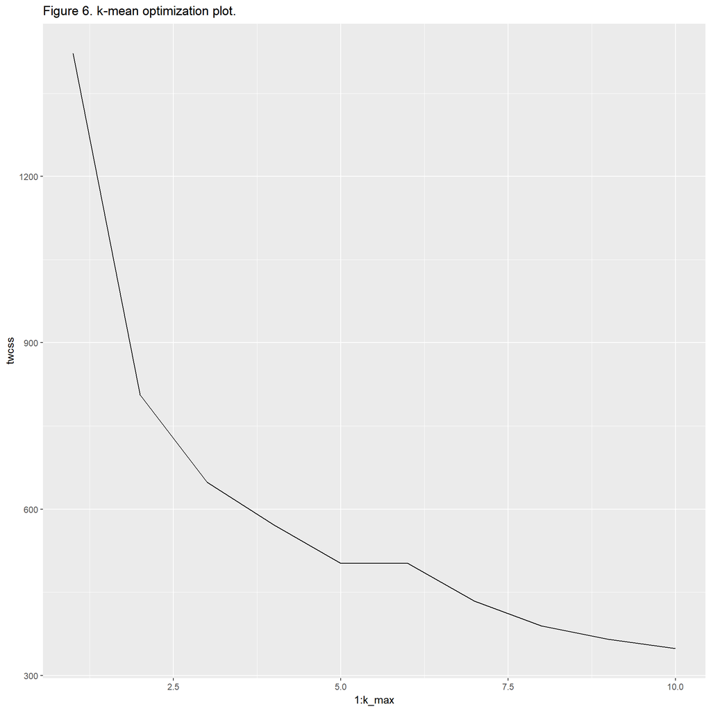

```r
library(ggplot2)
set.seed(123)
k_max <- 10
twcss <- sapply(1:k_max, function(k){kmeans(human2_scaled, k)$tot.withinss})
qplot(x = 1:k_max, y = twcss, geom = 'line', main = "Figure 6. k-mean optimization plot.")
```

The optimal number of clusters is when the total WCSS drops radically. In this case, the optimal K-means values is 2. The clusters are then visualised here:

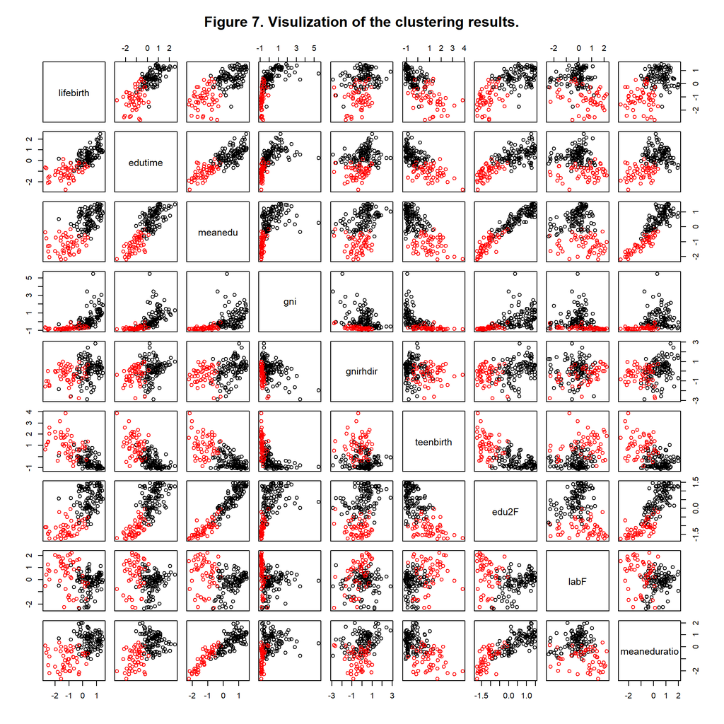

```r
km <-kmeans(human2_scaled, centers = 2)
pairs(human2_scaled, col = km$cluster, main = "Figure 7. Visulization of the clustering results.")
```

# 5 **Conclusions and discussion**

In the final project of the IODS course, I explored more about the `human` data. The techniques learnt during the course, such as linear regression and model validation, logistic regression, linear discriminat analysis and K-mean clustering are explored. The research questions raised were checked, verified and corrected according to the analysis results. Exercises about data wrangling was also done and seems to be quite interesting.

The results suggested that it is statistically clear that gender imbalance are more severe in underdeveloped and developing countries with low HDI index. And that HDI can successfuly predict the Adolences birth rate in the countries.

Data is not powerful without proper analysis and modern data science has enabled us with proper tools to dig deeper into the data and predict unknown or foreseeable data. This course is only the beginning of data analysis and already I felt very beneficial.